# Machine Learning in R with tidymodels

Jeffrey M. Girard | University of Kansas  
Technology in Psychiatry Summit 2022

[figure not shown]

# Overview

## Instructor

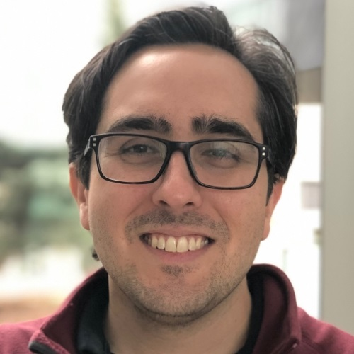

**Jeffrey Girard**, PhD  
www.jmgirard.com  
jmgirard@ku.edu

#### Background

- Assistant Professor, *University of Kansas*
- Research Postdoc, *Carnegie Mellon University*
- PhD Student, *University of Pittsburgh*

#### Research Areas

- Psychological/Clinical Assessment
- Affective/Interpersonal Communication
- Applied Statistics and Machine Learning
- Data Science and Software Engineering

## Workshop Overview

1. Conceptual Introductions
2. Walkthrough #1 (Classification)
3. Walkthrough #2 (Regression)
4. Advanced Previews
5. Question and Answer
6. Practice Assignments

## Workshop Datasets

- **Walkthrough #1 (Classification)**

  [Drug Consumption](https://raw.githubusercontent.com/jmgirard/tips2022ml/master/data/drug_consumption.csv) $(n=1876, p_{\text{cocaine_user}}=0.36)$

  *How well can we predict who is a cocaine user based on demographics, personality traits, and legal substance use?*
- **Walkthrough #2 (Regression)**

  [Cali House](https://raw.githubusercontent.com/jmgirard/tips2022ml/master/data/calihouse_2000.csv) $(n=2000, \text{Min}=\$15\text{k}, \text{Max}=\$500\text{k})$

  *How well can we predict the median house value of a block in 1990 California based on its houses, population, and location?*

# Conceptual Introductions

## What is machine learning?

- Machine learning (ML) is a **branch of computer science**
- ML researchers **develop algorithms** that learn from data
- When algorithms learn from data, they create **models**
- This workshop is about creating predictive models
- Our goal will be to **use known/available information**…
- To **predict unknown/unavailable information**…
- Ideally in a way that generalized to **novel/unseen data**

*Note.* ML researchers also create models for other purposes (e.g., data generation).

## Roles in Predictive Modeling

Labels / Outcomes

- Labels are variables we want to predict the unknown values of
- Labels tend to be **expensive** or **difficult to measure** in new data
- Labels may also describe **subjective** experiences or **future** events
- *e.g., diagnoses, treatment response, substance use, suicide attempts*

Features / Predictors

- Features are variables we use to predict the unknown label values
- Features tend to be relatively **cheap** and **easy to measure** in new data
- *e.g., demographics, self-reports, digital behavior, neurobiology*

## Modes of Predictive Modeling

Classification

- When labels are categorical, predicting them is called “classification”
- *e.g., Will this patient respond to treatment or not?*
- *e.g., Is this patient depressed, euthymic, or manic?*

Regression

- When labels are continuous, predicting them is called “regression”
- *e.g., How many days will the patient be hospitalized for?*
- *e.g., How much of the drug will be in the patient’s blood?*

*Note.* Unsupervised ML (or “data mining”) has no explicit labels.

## Comprehension Check

Ann has developed an ML system that looks at a patient’s physiological signals and tries to determine whether they are having a micro-seizure.

1. The features are the _____  
and the labels are the _____.

1. physiological signals;  
   physiological signals
2. physiological signals;  
   micro-seizure (yes/no)
3. micro-seizure (yes/no);  
   physiological signals
4. micro-seizure (yes/no);  
   micro-seizure (yes/no)

**2. Which “mode” of predictive modeling is Ann using for her ML system?**

1. Regression
2. Classification
3. Unsupervised Learning
4. Data Mining

## Machine Learning Steps

- **Data Preparation**: Importing, Tidying, Splitting
- **Model Development**: Feature Engineering, Model Specification
- **Model Tuning**: Resampling, Optimization, Selection
- **Model Evaluation**: Performance, (Comparison), (Utility)
- **Model Use**: Explanation, (Deployment), (Updating)

## Signal and Noise

## Under and Overfitting

## Bias and Variance

## Use cases for ML

# Classification Example

Predict cocaine use from demographics and personality

## 1. Import and tidy data

We load our data from a local text (i.e., CSV) file

We coerce all categorical variables to explicit factors

We retain only features/predictors and our label/outcome

```r
# Load the tidyverse package for data reading and tidying
library(tidyverse)

drugs <-
  # Read in data from CSV file
  read_csv("./data/drug_consumption.csv", show_col_types = FALSE) |>
  # Transform categorical variables into factors
  mutate(
    across(c(Age:Ethnicity, Caff:Nicotine), factor),
    Coke = factor(Coke, levels = c(1, 0))  # Set positive class first
  ) |>
  # Drop unneeded variables
  select(Age:Nicotine, Coke)
```

*Note.* Read [“R for Data Science”](https://r4ds.had.co.nz/) to learn about efficient data tidying in R.

## 2. Split data for training and testing

We use 80% of the data for “training” and 20% for “testing”

We stratify both sets by our outcome variable (cocaine use)

```r
# Load the tidymodels package for machine learning
library(tidymodels)

# Set random number generation seed for reproducibility
set.seed(2022)

# Create initial split for holdout validation
coke_split <- initial_split(drugs, prop = 0.8, strata = Coke)

# Extract and save the training set (for development and tuning)
coke_train <- training(coke_split)

# Extract and save the testing set (for evaluation only)
coke_test <- testing(coke_split)
```

*Note.* Stratification ensures a similar distribution across all splits.